# Getting started with xplaineff

## What xplaineff does

Global feature effect methods such as partial dependence (PD) and accumulated local effects (ALE) describe how a fitted model’s prediction changes, on average, when one feature is varied. Because they average over all observations, they can hide feature interactions: the effect of a feature may look flat globally while being strongly positive in one subgroup and strongly negative in another.

**xplaineff** implements the GADGET algorithm (Generalized Additive Decomposition of Global EffecTs; Herbinger et al., 2024). GADGET recursively partitions the feature space on so-called *split features* so that, within each region, the effects of the *features of interest* are as homogeneous as possible across observations. The result is a shallow tree whose nodes are regions with their own regional PD or ALE curves. Splits reveal which features interact, and the regional curves show how the effect changes between regions.

The package exposes three R6 classes:

| Class | Role |
| --- | --- |
| `GadgetTree` | The tree: `$new()`, `$fit()`, `$extract_split_info()`, `$plot_tree_structure()`, `$plot()` |
| `PdStrategy` | Heterogeneity and plots based on PD and individual conditional expectation (ICE) curves |
| `AleStrategy` | Heterogeneity and plots based on ALE |

A typical workflow has four steps:

1. Train any supervised model (for example with **mlr3**).
2. Choose a strategy (`PdStrategy` or `AleStrategy`) and create a `GadgetTree` with the stopping rules you want.
3. Call `$fit()` with the training data, the target column, the model, and optionally the features of interest (`feature_set`) and the candidate split features (`split_feature`).
4. Inspect the result with `$extract_split_info()`, `$plot_tree_structure()`, and `$plot()`.

```r
library(xplaineff)
```

## Example 1: a PD tree on synthetic data

We start with a small simulated data set in which the effect of `x2` is moderated by `x3`: the slope of `x2` is `+3` when `x3 > 0.3` and `-3` otherwise. A global PD curve for `x2` would average these two regimes and look almost flat.

```r
set.seed(1)
n = 500
x1 = runif(n, -1, 1)
x2 = runif(n, -1, 1)
x3 = runif(n, -1, 1)
y = 0.2 * x1 + ifelse(x3 > 0.3, 3, -3) * x2 + rnorm(n, 0, 0.3)
syn_data = data.frame(x1, x2, x3, y)
```

Any model with a `predict()` method can be explained. Here we use a linear model with the correct interaction term so that the example runs without extra packages.

```r
syn_model = lm(y ~ x1 + x2 * I(x3 > 0.3), data = syn_data)
```

We now grow a PD tree. `feature_set` names the feature of interest whose effect we want to decompose, and `split_feature` lists the features allowed to define regions. The constructor arguments control when the tree stops growing:

- `n_split`: maximum number of splits (tree depth).
- `min_node_size`: minimum number of observations per child node.
- `n_quantiles`: number of quantile-based candidate split points per numeric split feature.
- `impr_par`: minimum relative improvement in heterogeneity required to accept a split.

The PD-specific argument `n_grid` sets the number of grid points at which the PD and ICE curves are evaluated.

```r
syn_tree = GadgetTree$new(
  strategy = PdStrategy$new(),
  n_split = 2,
  min_node_size = 50,
  n_quantiles = 40
)
syn_tree$fit(
  data = syn_data,
  target_feature_name = "y",
  model = syn_model,
  feature_set = "x2",
  split_feature = c("x1", "x3"),
  n_grid = 20L
)
```

`extract_split_info()` returns one row per node.

```r
syn_split = syn_tree$extract_split_info()
print(
  syn_split[, c("id", "depth", "n_obs", "node_type", "split_feature", "split_value", "int_imp", "is_final")],
  row.names = FALSE, digits = 2
)
```

```
#>  id depth n_obs node_type split_feature split_value int_imp is_final
#>   1     1   500      root            x3        0.31    0.99    FALSE
#>   2     2   329      left          <NA>          NA      NA     TRUE
#>   3     2   171     right          <NA>          NA      NA     TRUE
```

The root split recovers the moderator `x3` close to the true threshold of `0.3`. `int_imp` is the improvement in heterogeneity achieved by the split, normalized by the root heterogeneity; a value near one means the split removes almost all of the heterogeneity of the `x2` effect. Both child nodes are leaves (`is_final = TRUE`): within each `x3` regime the effect of `x2` is homogeneous, so the tree stops before reaching `n_split`.

`plot()` draws the regional PD and ICE curves for every node. With `show_plot = FALSE` it only returns the plots as a nested list named by depth and node id, which is convenient for choosing what to display.

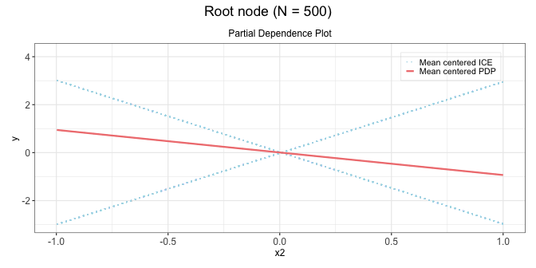

```r
syn_plots = syn_tree$plot(
  data = syn_data,
  target_feature_name = "y",
  show_plot = FALSE
)
syn_plots$Depth_1$Node_1
```

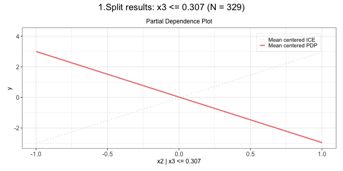

```r
syn_plots$Depth_2$Node_2
```

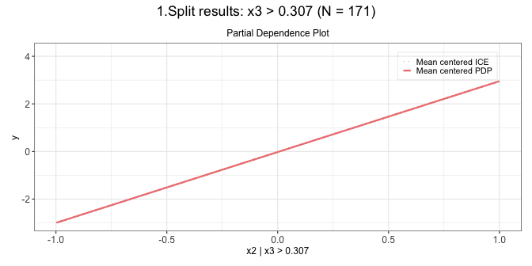

```r
syn_plots$Depth_2$Node_3
```

At the root the ICE curves fan out in two directions and the averaged PD curve is nearly flat. After the split, each region shows one clean linear effect with the expected sign.

## Example 2: a PD tree on the bike-sharing data

The remaining examples use the `Bikeshare` data from **ISLR2** and a random forest trained with **mlr3**. They are evaluated only if these packages are installed.

```r
library(mlr3)
library(mlr3learners)
data("Bikeshare", package = "ISLR2")
set.seed(123)
bike = Bikeshare[sample(seq_len(nrow(Bikeshare)), 1000), ]
factor_features = c("season", "mnth", "weekday", "workingday", "holiday", "weathersit")
bike[factor_features] = lapply(bike[factor_features], as.factor)
bike_data = bike[, c("hr", "temp", "workingday", "season", "mnth", "day", "holiday", "weekday",
  "weathersit", "atemp", "hum", "windspeed", "bikers")]
names(bike_data)[names(bike_data) == "bikers"] = "target"

task = TaskRegr$new(id = "bike", backend = bike_data, target = "target")
learner = lrn("regr.ranger")
learner$train(task)
```

The target is the hourly number of bikers. We decompose the effects of `hr`, `temp`, `workingday`, and `season`, and allow `temp`, `workingday`, and `season` to define regions. Categorical split features must be factors; the package converts character columns automatically but treats numeric 0/1 indicators as numeric unless they are encoded as factors beforehand.

```r
effect_features = c("hr", "temp", "workingday", "season")
split_features = c("temp", "workingday", "season")

bike_pd = GadgetTree$new(
  strategy = PdStrategy$new(),
  n_split = 2,
  min_node_size = 50
)
bike_pd$fit(
  data = bike_data,
  target_feature_name = "target",
  model = learner,
  feature_set = effect_features,
  split_feature = split_features,
  n_grid = 20L
)
```

`plot_tree_structure()` draws the tree with the split conditions and node sizes.

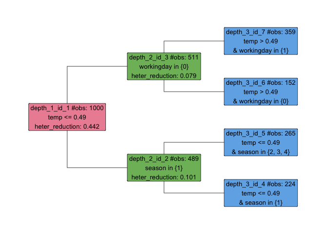

```r
bike_pd$plot_tree_structure()
```

```r
bike_pd_split = bike_pd$extract_split_info()
print(
  bike_pd_split[, c("id", "depth", "n_obs", "node_type", "split_feature", "split_value", "int_imp", "is_final")],
  row.names = FALSE, digits = 2
)
```

```
#>  id depth n_obs node_type split_feature split_value int_imp is_final
#>   1     1  1000      root          temp        0.49    0.44    FALSE
#>   2     2   489      left        season           1    0.10    FALSE
#>   3     2   511     right    workingday           0    0.08    FALSE
#>   4     3   224      left          <NA>        <NA>      NA     TRUE
#>   5     3   265     right          <NA>        <NA>      NA     TRUE
#>   6     3   152      left          <NA>        <NA>      NA     TRUE
#>   7     3   359     right          <NA>        <NA>      NA     TRUE
```

The root split separates cooler and warmer hours on `temp`. Each branch is then refined by a categorical feature. For a categorical split, `split_value` is the level that defines the partition. With `PdStrategy` (one-vs-rest splits) it is the single level sent to the left child; with `AleStrategy` (ordered-prefix splits) it is the last level of the ordered prefix sent to the left child. The tree plot shows the complete level sets of both children.

Regional curves for a single feature are obtained with the `features` argument. We look at the hourly pattern at the root and in its two children.

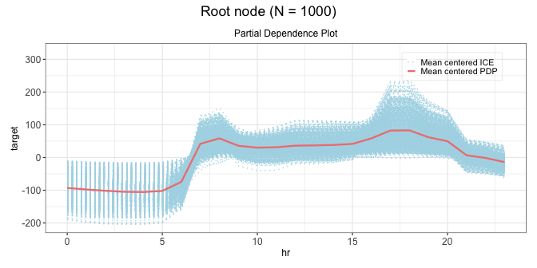

```r
bike_pd_plots = bike_pd$plot(
  data = bike_data,
  target_feature_name = "target",
  features = "hr",
  show_plot = FALSE
)
bike_pd_plots$Depth_1$Node_1
```

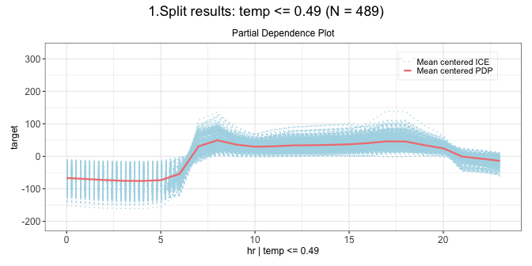

```r
bike_pd_plots$Depth_2$Node_2
```

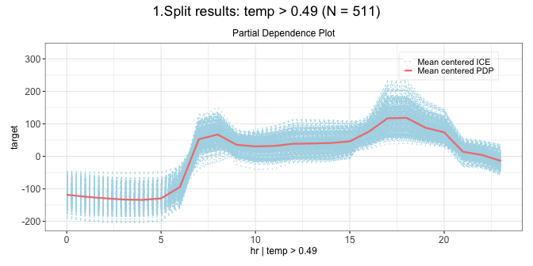

```r
bike_pd_plots$Depth_2$Node_3
```

At the root the ICE curves for `hr` spread widely around the PD curve. Within each temperature region the curves are more concentrated, and the two regions differ in the strength of the evening peak.

## Example 3: an ALE tree on the bike-sharing data

`AleStrategy` uses the same interface. ALE is computed internally from the model; the ALE-specific argument `n_intervals` sets the number of intervals used for accumulation. Here we also set `impr_par` so that only splits with a relative improvement of at least one percent are accepted.

```r
bike_ale = GadgetTree$new(
  strategy = AleStrategy$new(),
  n_split = 2,
  impr_par = 0.01,
  min_node_size = 50
)
bike_ale$fit(
  data = bike_data,
  target_feature_name = "target",
  model = learner,
  feature_set = effect_features,
  split_feature = split_features,
  n_intervals = 10
)
bike_ale_split = bike_ale$extract_split_info()
print(
  bike_ale_split[, c("id", "depth", "n_obs", "node_type", "split_feature", "split_value", "int_imp", "is_final")],
  row.names = FALSE, digits = 2
)
```

```
#>  id depth n_obs node_type split_feature split_value int_imp is_final
#>   1     1  1000      root    workingday           0    0.53    FALSE
#>   2     2   316      left        season           1    0.02    FALSE
#>   3     2   684     right          temp        0.47    0.16    FALSE
#>   4     3    72      left          <NA>        <NA>      NA     TRUE
#>   5     3   244     right          <NA>        <NA>      NA     TRUE
#>   6     3   316      left          <NA>        <NA>      NA     TRUE
#>   7     3   368     right          <NA>        <NA>      NA     TRUE
```

The ALE tree may choose a different root split than the PD tree, because PD and ALE measure heterogeneity on different scales: PD compares whole ICE curves, whereas ALE compares local prediction differences within intervals. Both views are valid; comparing them is a useful robustness check.

For ALE the `int_imp_<feature>` columns of the split table additionally report, for each feature of interest, the reduction of that feature’s own heterogeneity achieved by the split, relative to its heterogeneity at the root.

```r
print(
  bike_ale_split[!bike_ale_split$is_final,
    c("id", "split_feature", setdiff(grep("^int_imp_", names(bike_ale_split), value = TRUE), "int_imp_parent"))],
  row.names = FALSE, digits = 2
)
```

```
#>  id split_feature int_imp_hr int_imp_temp int_imp_workingday int_imp_season
#>   1    workingday       0.21         0.09                  1           0.02
#>   2        season       0.03         0.01                  0           0.09
#>   3          temp       0.38         0.00                  0           0.03
```

Regional ALE curves are drawn in the same way. `mean_center = TRUE` (the default) centers each curve, which makes shapes easier to compare across regions.

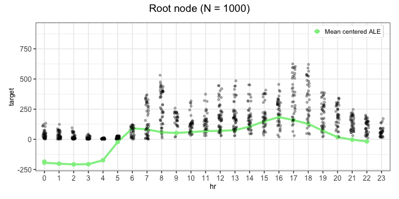

```r
bike_ale_plots = bike_ale$plot(
  data = bike_data,
  target_feature_name = "target",
  features = "hr",
  show_plot = FALSE
)
bike_ale_plots$Depth_1$Node_1
```

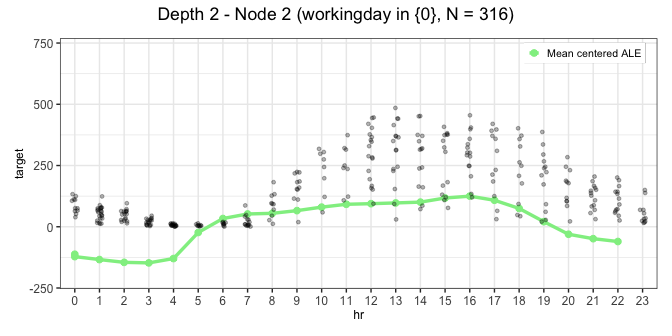

```r
bike_ale_plots$Depth_2$Node_2
```

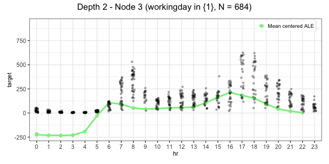

```r
bike_ale_plots$Depth_2$Node_3
```

## Controlling the output

`plot()` accepts a few arguments that are shared by both strategies:

- `depth` and `node_id` restrict the output to particular tree levels or nodes; node ids are the ones shown by `plot_tree_structure()` and in the `id` column of the split table.
- `features` selects the features of interest to draw.
- `show_plot = FALSE` suppresses printing and only returns the list of ggplot objects.
- `show_point` overlays the observed data points, and `mean_center` toggles centering of the curves.

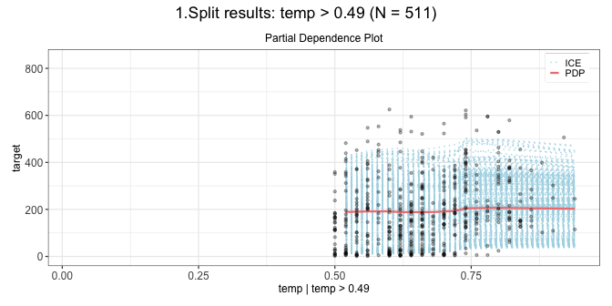

```r
one_plot = bike_pd$plot(
  data = bike_data,
  target_feature_name = "target",
  features = "temp",
  depth = 2,
  node_id = 3,
  show_point = TRUE,
  mean_center = FALSE,
  show_plot = FALSE
)
one_plot$Depth_2$Node_3
```

`extract_split_info(include_timing = TRUE)` adds the time spent searching each split, which is helpful when tuning `n_quantiles` or `n_grid` on larger data.

## Using precomputed effects

For `PdStrategy` you can pass ICE curves computed with **iml** instead of a model. This is useful if you already have a `FeatureEffects` object or want full control over the prediction function.

```r
library(iml)
predictor = Predictor$new(
  model = learner,
  data = bike_data[, setdiff(names(bike_data), "target")],
  y = bike_data$target
)
effects = FeatureEffects$new(predictor, features = effect_features, method = "ice", grid.size = 20)

bike_pd_iml = GadgetTree$new(strategy = PdStrategy$new(), n_split = 2, min_node_size = 50)
bike_pd_iml$fit(
  data = bike_data,
  target_feature_name = "target",
  effect = effects,
  split_feature = split_features
)
bike_pd_iml$plot(effect = effects, data = bike_data, target_feature_name = "target", features = "hr")
```

`AleStrategy` always computes ALE internally, because the split search needs observation-level local effects that interval-level ALE summaries from other packages do not provide.

## Categorical split features

Both strategies can split on categorical features. How the candidate splits are formed is set in the strategy constructor through `categorical_split`:

- `PdStrategy$new(categorical_split = "one_vs_rest")` (default) tries one level against all others.
- `AleStrategy$new(categorical_split = "ordered_prefix")` (default) orders the levels and tries all prefix partitions of that order.
- `categorical_split = "exhaustive"` searches all level subsets for either strategy; `max_exhaustive_levels` caps the number of levels for which this is attempted.

For `AleStrategy`, the level order used by `"ordered_prefix"` is chosen through the `order_method` argument of `$fit()`:

- `"raw"` (default) keeps the factor level order.
- `"mds"` and `"pca"` derive a data-driven order from the other features, which helps when the levels have no natural order.
- `"random"` uses a random order and is mainly useful as a baseline.

## References

Herbinger, J., Wright, M. N., Nagler, T., Bischl, B., and Casalicchio, G. (2024). Decomposing global feature effects based on feature interactions. *Journal of Machine Learning Research*, 25(381), 1–65. https://jmlr.org/papers/v25/23-0699.html